# Who plays video games

# 2. Basic Analysis

### 2.0 Data Processing

There are two original data sets, which are viedodata and videoMultiple resprectively.Having a brief glance on these two sets, we could easily found that there are some 99 inside. Based on the statement of every variables provided, we can decide that there 99s are missing value. So as to make the analysis more accurate, we simply replace these missing values to NA.

```r
# Open the file and redefine the make
setwd("~/Downloads")
```

```
The working directory was changed to /Users/barryzhang/Downloads inside a notebook chunk. The working directory will be reset when the chunk is finished running. Use the knitr root.dir option in the setup chunk to change the working directory for notebook chunks.
```

```r
vd <- read.table("videodata.txt", header=TRUE)
vm <- read.table("videoMultiple.txt", header=TRUE)
```

Clean and wash the data. Replacing all 99 here to NA.

```r
vd[vd == 99] <- NA
vm[vm == 99] <- NA
```

Simple observations and summary about the data sets

```r
# Find the numner of students in different like standard
length(which(vd$like == '1'))
```

```
[1] 1
```

```r
length(which(vd$like == '2'))
```

```
[1] 23
```

```r
length(which(vd$like == '3'))
```

```
[1] 46
```

```r
length(which(vd$like == '4'))
```

```
[1] 13
```

```r
length(which(vd$like == '5'))
```

```
[1] 7
```

### 2.1 Fraction Analysis

So as to have a estimate of the the fraction about students played video games the week prior the survey. We will construct a point estimate and a interval estimate.

Point Estimate

```r
# Number of people who played the video games
n = length(which(vd$time > '0'))
n
```

```
[1] 34
```

```r
# Estimator
X_bar = n / length(vd$time)
X_bar
```

```
[1] 0.3736264
```

```r
# Estimator of SE
SE = ((X_bar * (1 - X_bar))^(0.5)) / (length(vd$time))^(0.5)
SE
```

```
[1] 0.05071247
```

```r
# Standard deviation
sd(vd$time)
```

```
[1] 3.77704
```

Interval Estimate ( Comfidence Interval) In this part we choose the significanve level as 5%

```r
# 95% confidence interval
CI = c(X_bar - 2 * SE, X_bar + 2 * SE)
CI
```

```
[1] 0.2722014 0.4750513
```

Complement code helping to find the mean of likeness of people who did not play games.

```r
nplay = subset(vd, vd$time == 0)
mean(nplay$like, na.rm = TRUE)
```

```
[1] 3.285714
```

### 2.2 Numerical Analysis for Playing Time vs. Frequency of Play

Checking to see how the amount of time spend playing video games in the week prior to the survey compared with every reproted frequency.

```r
# Create 4 subsets by frequence.
f1 = subset(vd, vd$freq == 1)
f2 = subset(vd, vd$freq == 2)
f3 = subset(vd, vd$freq == 3)
f4 = subset(vd, vd$freq == 4)
```

Find the average playing time for each subset, and the standard error

```r
# The average playing time
mean(f1$time)
```

```
[1] 4.444444
```

```r
mean(f2$time)
```

```
[1] 2.539286
```

```r
mean(f3$time)
```

```
[1] 0.05555556
```

```r
mean(f4$time)
```

```
[1] 0.04347826
```

```r
# standard error
sd(f1$time)/(nrow(f1))^(0.5)
```

```
[1] 1.856753
```

```r
sd(f2$time)/(nrow(f2))^(0.5)
```

```
[1] 1.039222
```

```r
sd(f3$time)/(nrow(f3))^(0.5)
```

```
[1] 0.0381108
```

```r
sd(f4$time)/(nrow(f4))^(0.5)
```

```
[1] 0.04347826
```

Number of people in each groups and the relative proportions

```r
# number of people
nrow(f1)
```

```
[1] 9
```

```r
nrow(f2)
```

```
[1] 28
```

```r
nrow(f3)
```

```
[1] 18
```

```r
nrow(f4)
```

```
[1] 23
```

```r
# proportion of people in certain group among the total sample size
nrow(f1) / nrow(vd)
```

```
[1] 0.0989011
```

```r
nrow(f2) / nrow(vd)
```

```
[1] 0.3076923
```

```r
nrow(f3) / nrow(vd)
```

```
[1] 0.1978022
```

```r
nrow(f4) / nrow(vd)
```

```
[1] 0.2527473
```

```r
# proportion of people who played the game in each group
length(which(f1$time > 0)) / nrow(f1)
```

```
[1] 0.7777778
```

```r
length(which(f2$time > 0)) / nrow(f2)
```

```
[1] 0.8571429
```

```r
length(which(f3$time > 0)) / nrow(f3)
```

```
[1] 0.1111111
```

```r
length(which(f4$time > 0)) / nrow(f4)
```

```
[1] 0.04347826
```

### 2.3 Average Amount of Time Spent Playing Video Games

So as to have a estimate the avergae amount of time spend playing video in the week prior to the survey, followings will construct a point and interval estimate and have simulation study, bootstrap. Point Estimate

```r
X = vd$time
n = nrow(vd)

# Estimator, Xbar
Xbar = mean(X)
Xbar
```

```
[1] 1.242857
```

```r
# Standard error of estimator
SEx = sd(X) / sqrt(n)
SEx
```

```
[1] 0.3959414
```

```r
# Find the mode of the time and the standard deviation
getmode <- function(v) {
     uniqv <- unique(v)
     uniqv[which.max(tabulate(match(v, uniqv)))]
}
getmode(vd$time)
```

```
[1] 0
```

```r
sd(vd$time)
```

```
[1] 3.77704
```

Interval Estimate ( Comfidence Interval) In this part we choose the significanve level as 5%

```r
CI = c(Xbar - 2 * SEx, Xbar + 2 * SEx)
CI
```

```
[1] 0.4509744 2.0347399
```

Bootstrap (Silulation study)

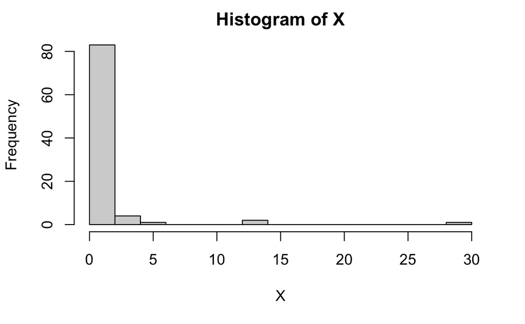

```r
# Distribution of time
hist(X, breaks = 20)
```

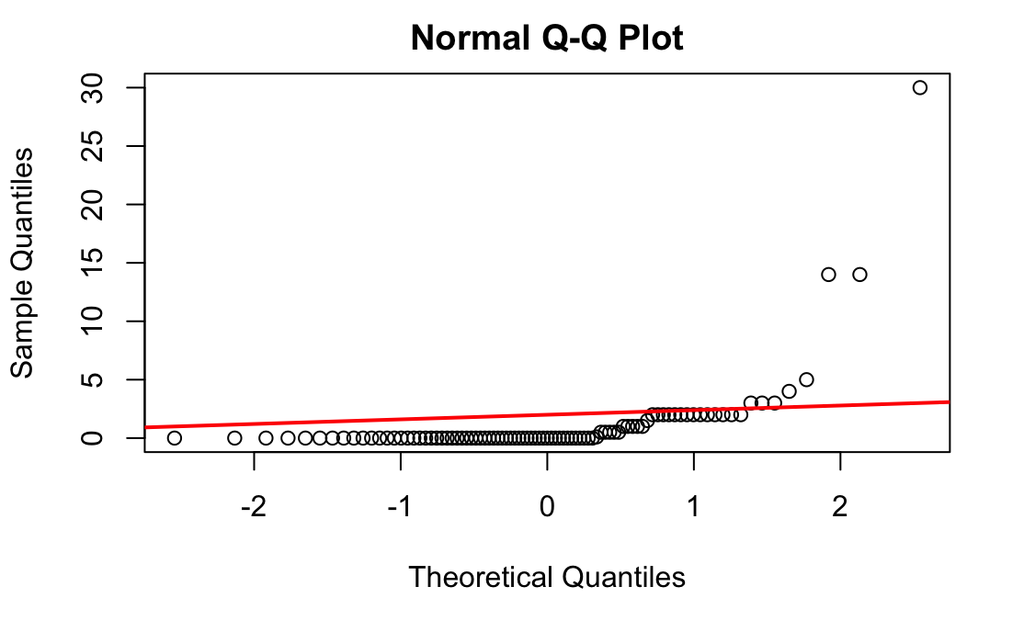

```r
qqnorm(X)
abline(X, SEx, col='red', lwd=2)
```

```r
# Bootstrap
B <- 500
Xbar.b <- rep(NULL, B)
for(b in 1:B) {
  X.b = sample(vd$time, n, replace = T)
  Xbar.b[b] <- mean(X.b)
}

# Compare bootstrap distribution to normal theory
hist(Xbar.b, breaks = 20, freq = F)
curve(dnorm(x, Xbar, SEx), 0, 3, col='red', lwd=2, add = T)
```

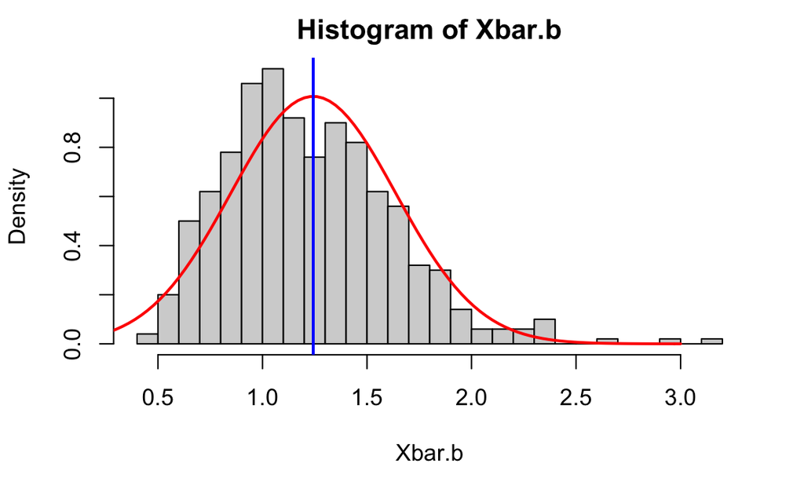

```r
abline(v = Xbar, col='blue', lwd=2)
```

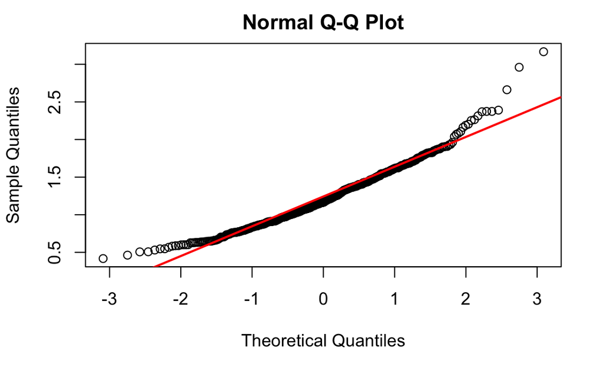

```r
qqnorm(Xbar.b)
abline(Xbar, SEx, col='red', lwd=2)
```

Find several feathers of Bootstrap (Numerically)

```r
# Find the mean, Standard Error and the standard deviation
mean(Xbar.b)
```

```
[1] 1.222767
```

```r
SEb = sd(Xbar.b) / sqrt(500)
SEb
```

```
[1] 0.01795966
```

```r
sd(Xbar.b)
```

```
[1] 0.4015903
```

```r
# Bootstrap CI
quantile(Xbar.b, c(0.025, 0.975))
```

```
     2.5%     97.5%
0.6010989 2.1349176
```

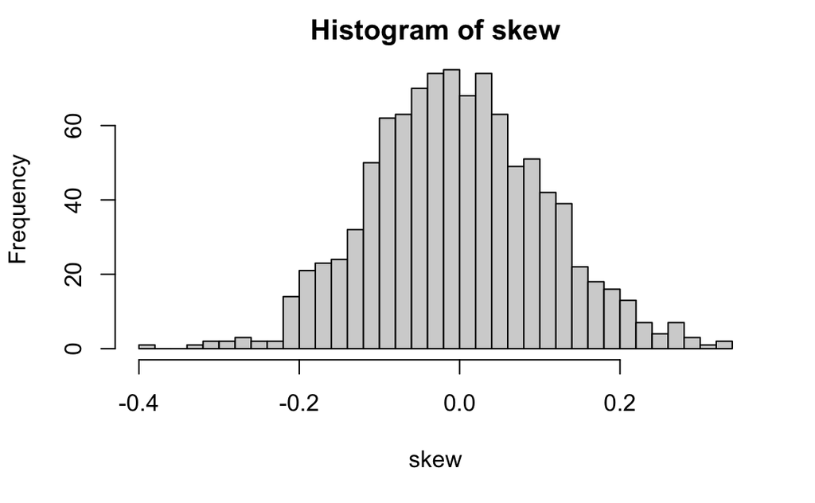

```r
# skewness and kurtosis of the bootstrap distribution of Xbars
# Define the functions abuot skewness and kurtosis
skewness <- function(X) mean(((X - mean(X))/sd(X))^3)
kurtosis <- function(X) mean(((X - mean(X))/sd(X))^4)
nsim <- 1000
skew <- rep(NULL, nsim)
kurt <- rep(NULL, nsim)
for(k in 1:nsim) {
  skew[k] <- skewness(rnorm(B))
  kurt[k] <- kurtosis(rnorm(B))
}
hist(skew, breaks = 50)
abline(v = skewness(Xbar.b), col='blue', lwd=2)
```

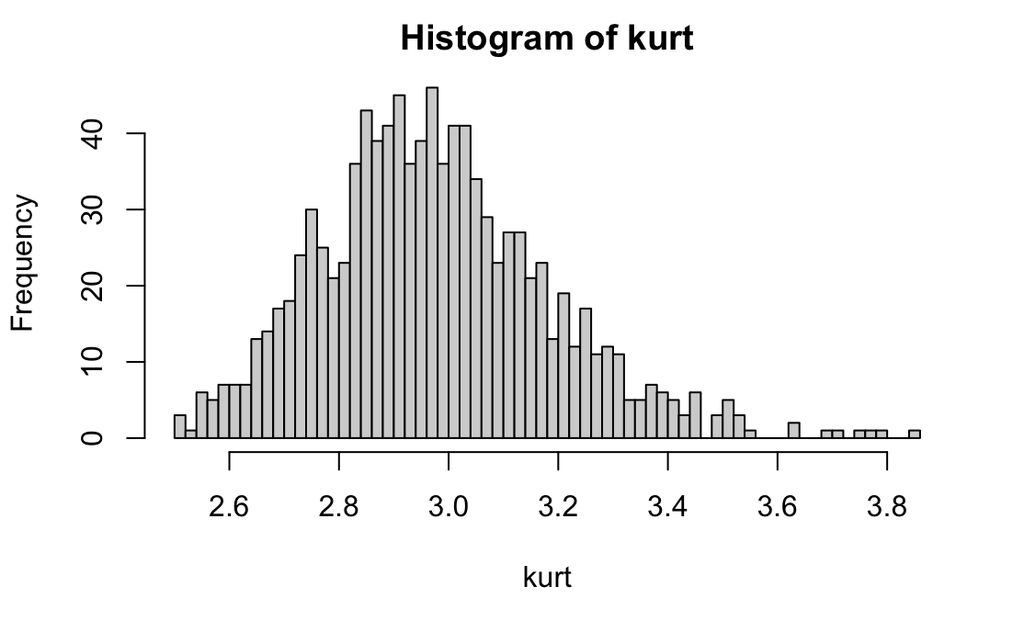

```r
hist(kurt, breaks = 50)
abline(v = kurtosis(Xbar.b), col='blue', lwd=2)
```

```r
# Find the mean of skewness and kurtosis
mean(skew)
```

```
[1] -0.001906057
```

```r
mean(kurt)
```

```
[1] 2.975246
```

```r
skewness(X)
```

```
[1] 5.693416
```

```r
kurtosis(X)
```

```
[1] 39.80964
```

### 2.4 “Attitude” for Student Playing Video Games

To figure out, in general, if students enjoy playing video games. By compare several proportions of different reasons, we could have a soutcut list about some main reasons why students enjoy or not thr games. Find the mean of the average likness

```r
mean(vd$like, na.rm = TRUE)
```

```
[1] 3.022222
```

```r
getmode(vd$like)
```

```
[1] 3
```

Find proporition of different reasons

```r
# Graphics/Realism
G = length(which(vm$graphic > 0)) / nrow(vm)
# Relaxation
R = length(which(vm$relax > 0)) / nrow(vm)
# Eye/hand coordination
E = length(which(vm$coord > 0)) / nrow(vm)
# Mental Challenge
M = length(which(vm$challenge > 0)) / nrow(vm)
# Feeling of mastery
F1 = length(which(vm$master > 0)) / nrow(vm)
# Bored
B1 = length(which(vm$bored > 0)) / nrow(vm)

# Too much time
T1 = length(which(vm$time > 0)) / nrow(vm)
# Frustrating
F2 = length(which(vm$frust > 0)) / nrow(vm)
# Lonely
L = length(which(vm$lonely > 0)) / nrow(vm)
# Too many rules
T2 = length(which(vm$rules > 0)) / nrow(vm)
# Costs too much
C = length(which(vm$cost > 0)) / nrow(vm)
# Boring
B2 = length(which(vm$boring > 0)) / nrow(vm)
# Friend’s don’t play
F3 = length(which(vm$friends > 0)) / nrow(vm)
# It is pointless
I = length(which(vm$point > 0)) / nrow(vm)
```

Construct the bar plot showing the percentage directly

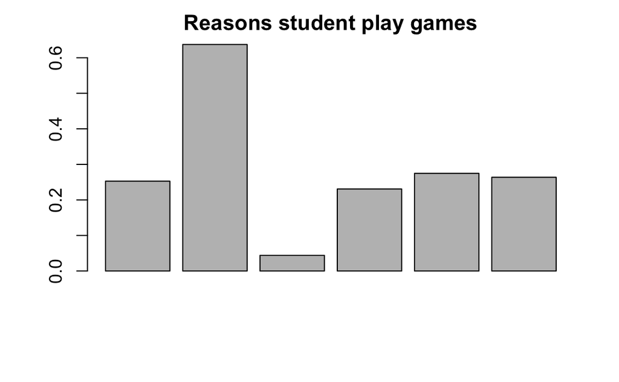

```r
# bar plot for reasons why student play games
slices1 <- c(G,R,E,M,F1,B1)
barplot(slices1, main="Reasons student play games")
```

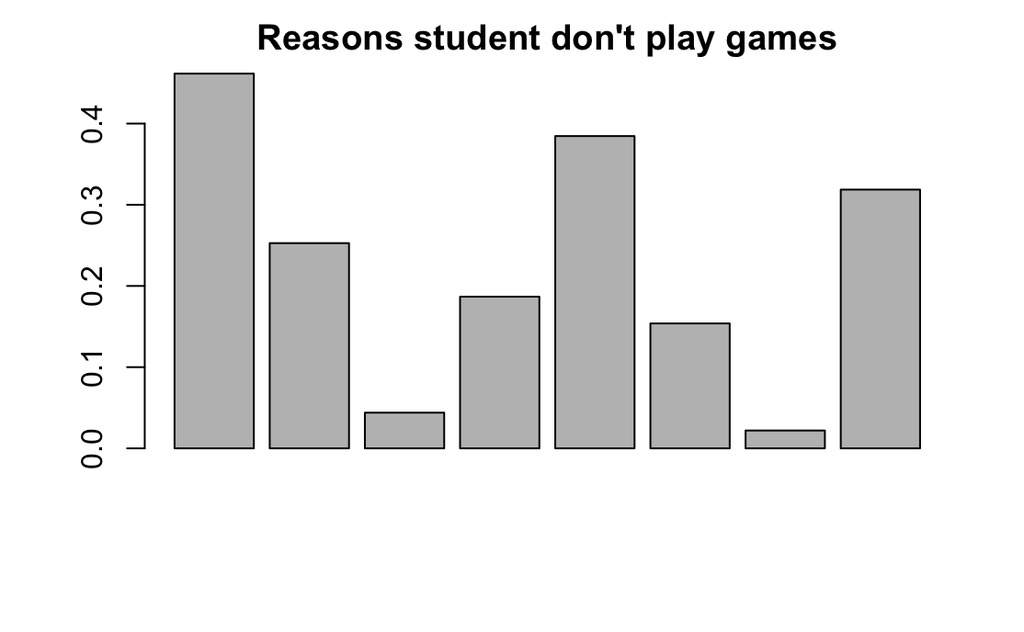

```r
# bar plot for reasons why student don't play games
slices2 <- c(T1, F2, L, T2, C, B2, F3, I)
barplot(slices2, main="Reasons student don't play games" )
```

```r
# male
Male = subset(vd, vd$sex == 1)

# female
Female = subset(vd, vd$sex == 0)
```

Find the numbers of students in each different variables and make the bar plot

```r
# Work
MW = length(which(Male$work > 0))
MNW = length(which(Male$work == 0))
MW
```

```
[1] 27
```

```r
MNW
```

```
[1] 23
```

```r
FW = length(which(Female$work > 0))
FNW = length(which(Female$work == 0))
FW
```

```
[1] 17
```

```r
FNW
```

```
[1] 21
```

```r
# Computer
MO = length(which(Male$own > 0))
MNO = length(which(Male$own == 0))
MO
```

```
[1] 40
```

```r
MNO
```

```
[1] 13
```

```r
FO = length(which(Female$own > 0))
FNO = length(which(Female$own == 0))
FO
```

```
[1] 27
```

```r
FNO
```

```
[1] 11
```

Construct the bar plot

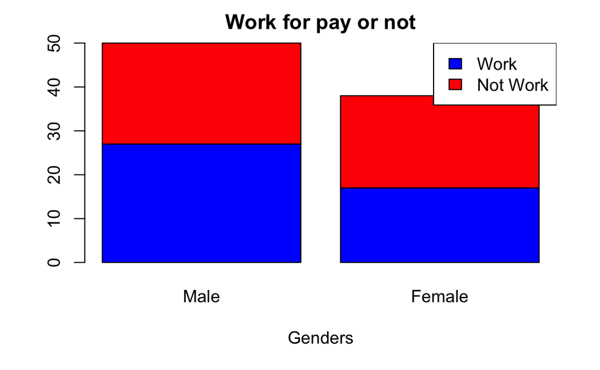

```r
# Work
counts <- matrix( c(27,17,23,21), ncol = 2, byrow = TRUE)
colnames(counts) = c("Male", "Female")
rownames(counts) = c("Work for pay", "Not work for pay")
counts <- as.table(counts)
barplot(counts, main="Work for pay or not",
  xlab="Genders", col=c("blue","red"))
legend("topright", c("Work", "Not Work"), fill = c("blue", "red"))
```

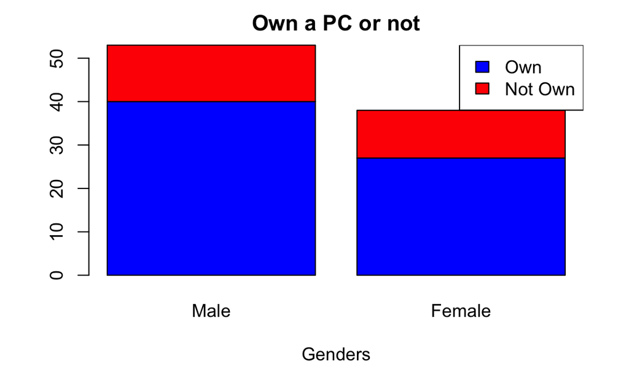

```r
# Computers
counts <- matrix( c(40,27,13,11), ncol = 2, byrow = TRUE)
colnames(counts) = c("Male", "Female")
rownames(counts) = c("Own a PC", "Not own a PC")
counts <- as.table(counts)
barplot(counts, main="Own a PC or not",
  xlab="Genders", col=c("blue","red"))
legend("topright", c("Own", "Not Own"), fill = c("blue", "red"))
```

### 2.6 Grade Analysis

Checking for if the grade distribution ideal, pi chart is the among the best approaches arrive this goal. Compare the percentage between real condition and the ideal one by looking throught the pi chart directly. Find the real proportion of the grades in this sample

```r
# number of people who get A, B, C, D and F
nA = length(which(vd$grade == 4))
nB = length(which(vd$grade == 3))
nC = length(which(vd$grade == 2))
nD = length(which(vd$grade == 1))
nF = length(which(vd$grade == 0))

# Find the proportion
pA = nA / nrow(vd)
pB = nB / nrow(vd)
pC = nC / nrow(vd)
pD = nD / nrow(vd)
pF = nF / nrow(vd)

pA
```

```
[1] 0.3406593
```

```r
pB
```

```
[1] 0.5714286
```

```r
pC
```

```
[1] 0.08791209
```

```r
pD
```

```
[1] 0
```

```r
pF
```

```
[1] 0
```

Construct the pie chart for both ideal and real one

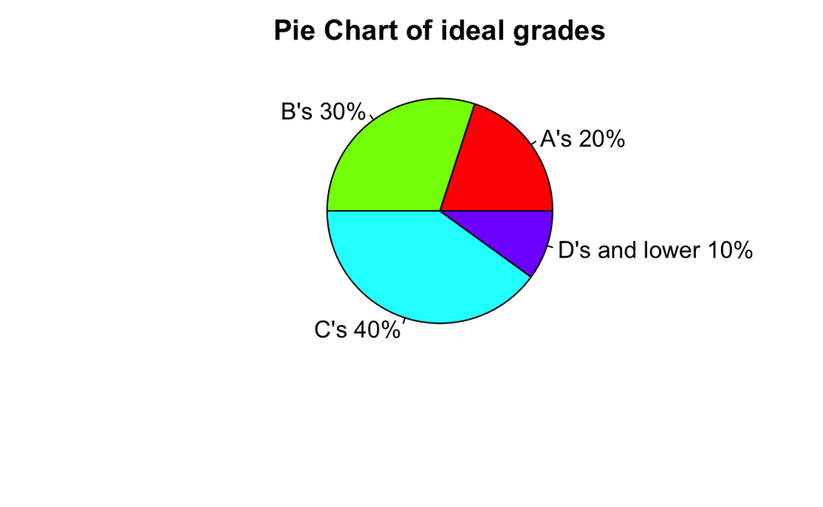

```r
# pi chart for ideal one
ideal = c(20,30,40,10)
lbls <- c("A's 20%", "B's 30%", "C's 40%", "D's and lower 10%")
pie(ideal, labels = lbls, col=rainbow(length(lbls)),main="Pie Chart of ideal grades")
```

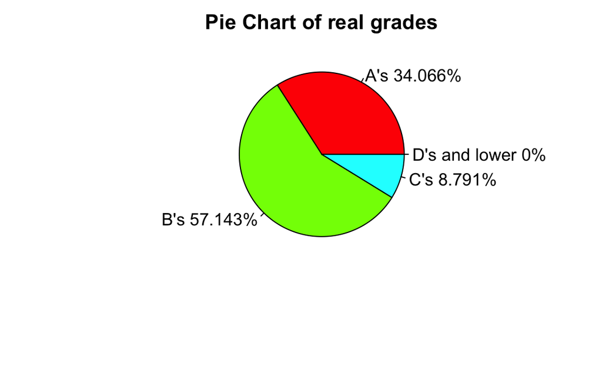

```r
# pi chart for real one
real = c(nA, nB,nC,nD+nF)
lbls2 = c("A's", "B's", "C's", "D's and lower")
pct <- round(c(pA,pB,pC,pD+pF)*100, 3)
lbls2 <- paste(lbls2, pct) # add percents to labels
lbls2 <- paste(lbls2,"%",sep="") # ad % to labels
pie(real,labels = lbls2, col=rainbow(length(lbls)),
   main="Pie Chart of real grades")
```

# 3. Advanced Analysis

So as to figure out if the average playing time of male and female students are the same, here, we construct a hypothesis test here. But first we have to process the variance hypothesis test first so as to determine if the varianves are the same. Then we can determine the degree of freedom.

Variance hypothesis test

```r
var.test(Male$time, Female$time)
```

```
    F test to compare two variances

data:  Male$time and Female$time
F = 3.4393, num df = 52, denom df = 37, p-value = 0.0001538
alternative hypothesis: true ratio of variances is not equal to 1
95 percent confidence interval:
 1.850596 6.196606
sample estimates:
ratio of variances
          3.439343
```

Means hypothesis test with unequal variances

```r
t.test(Male$time,Female$time,conf.level = 0.98)
```

```
    Welch Two Sample t-test

data:  Male$time and Female$time
t = 1.156, df = 83.441, p-value = 0.251
alternative hypothesis: true difference in means is not equal to 0
98 percent confidence interval:
 -0.8900313  2.5824841
sample estimates:
mean of x mean of y
 1.596226  0.750000
```